# Lesson 11: Corporate Credibility, Endorser, and Purchase Intent (3.1)

LTC James K. Starling

### Review

(-3) What types of design did we discuss in Chapter 2?

*block designs/matched pairs design (repeated measures) and observational studies.*

(-2) We saw from Ch. 1 that $SST = SSM + SSE$. How did this change in what we saw in Ch. 2? *What is the adjusted sum of squares*?

If we had blocking, we had something like the following: $SSM = SSM_{explanatory} + SSM_{blocking}$.

(-1) When would we want to block in a design? In other words, what assumption are we making when we use a block study design?

*The assumption is that the variation between blocks is a large source of variation.*

In this chapter we’re going to dive more into some design structures starting with full factorial designs.

**Background**: Our book talks about a study on corporate credibility where researchers recruited 160 female college students and gave them a pamphlet containing background information (positive or negative) on a fictional shoe company. Each student was then shown a celebrity endorsement for one of the products and asked to rate her attitude towards the brand as well as her purchase intent. The researchers are interested in how corporate credibility affects purchase intent, and whether corporate credibility matters more than endorser credibility (or vice versa).

1. Create a Sources of Variation diagram. What were the response variables and the explanatory variable(s)? How are these variables classified?

*Response-Favorability ratings or purchase intention (3-21)/quantitative. Explanatory variables-Corporate Credibility (Low, High) and Endorser (Flo Jo, Roseanne)/ both categorical/binary.*

2. Are any of these explanatory variables blocking variables? Why or why not.

*Neither of the variables are blocking variables because the students can be assigned to the groups. Blocking variables should be inherent characteristics of the experimental units. We block when we can and randomly assign what we cannot block.*

3. **Design 1:** The first design structure the researchers considered was to randomly assign 80 participants to the company with positive literature and Flo Jo and 80 participants to the company with negative literature and Roseanne. Is this a good design structure? Why or why not?

*No. The two explanatory variables might be associated with each other.If we did find out that one group was higher than the other we would not be able to determine whether it was because of the pamphlet or the endorser (aka complete confounding).*

4. **Design 2:** Then they thought ‘what if we split our population into two groups. One group will focus on the corporate credibility (positive or negative credibility) and the other group will focus on the endorser (Roseanne or Flo Jo)’. Is this a good design structure?

*No. Exposing each participant to only one of the two variables does not allow us to measure the combined effects of both endorser and corporate credibility.*

5. **Design 3:** Instead of manipulating the variables separately the researchers exposed a subset of the participants to every treatment. This is known as a *full factorial design*.

By the way, what’s a treatment? What does the ‘factor’ in factorial refer to? How many factors do we have (what are they)? How many treatments do we have (what are they)?

*Two factors (endorser and corporate credibility) and four treatments (every combination of endorser-pamphlet).*

6. If we want a balanced full factorial design, how many of our 160 participants should we assign to each treatment? What are the main advantages to this type of study design?

*We should assign 40 to each treatment group. The advantage to this study design where we randomly assigns the same number of experimental units to each treatment is that we remove the confounding. In other words, we are investigating two explanatory variables but we are able to separate out the changes in the individual variables. The importance of being able to separate out the confounding is going to be an important recurring theme is this example. This is known as 2x2 study- because the study has two factors, each with two levels.*

7. Can you foresee any potential problems with a full factorial design in general?

*If there are a lot of factors, the full factorial design would have a lot of treatment groups, i.e., inefficient and potentially expensive.*

9. Consider the graphs below. Explain what you see in the graphs.

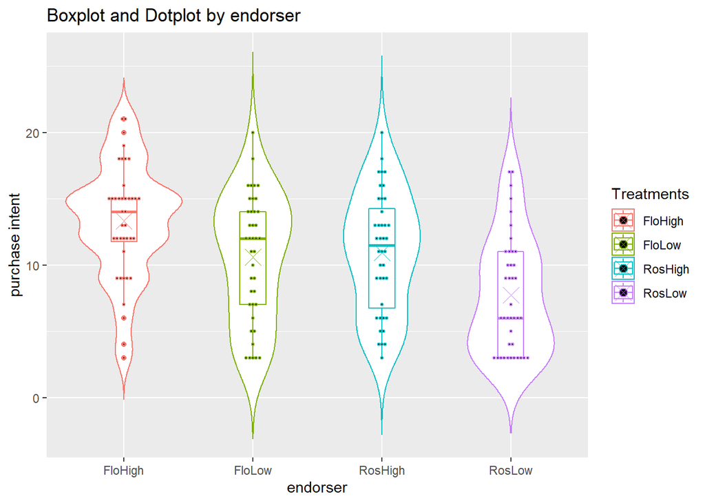

```r
cred %>% ggplot(aes(x=Treatments, y=PI, color=Treatments)) +
  geom_violin(trim=FALSE) +
  geom_boxplot(width=0.2) +
  geom_dotplot(binaxis='y', stackdir='center', dotsize=0.25, binwidth = 1) +
  stat_summary(fun=mean, geom="point", size=5, pch=4) +
  labs(y="purchase intent", x="endorser", title="Boxplot and Dotplot by endorser")
```

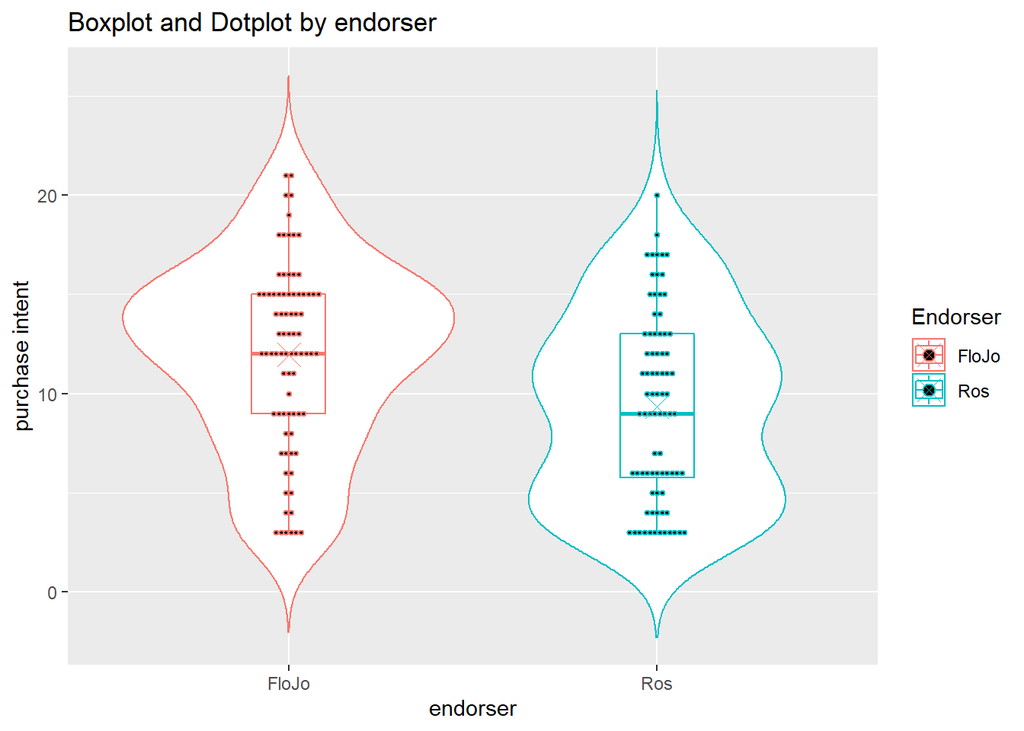

```r
cred %>% ggplot(aes(x=Endorser, y=PI, color=Endorser)) +
  geom_violin(trim=FALSE) +
  geom_boxplot(width=0.2) +
  geom_dotplot(binaxis='y', stackdir='center', dotsize=0.25, binwidth = 1) +
  stat_summary(fun=mean, geom="point", size=5, pch=4) +
  labs(y="purchase intent", x="endorser", title="Boxplot and Dotplot by endorser")
```

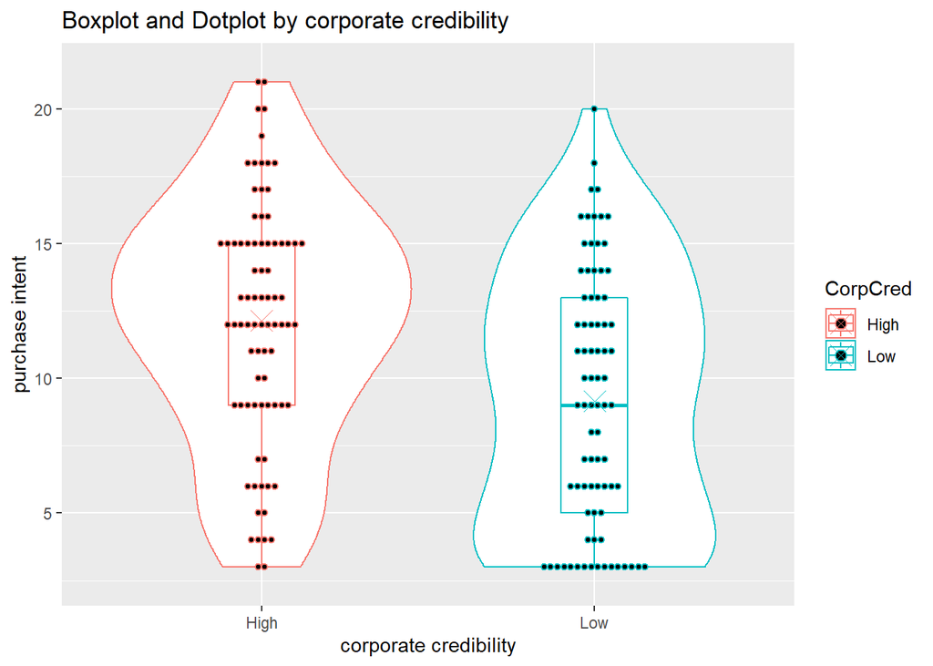

```r
cred %>% ggplot(aes(x=CorpCred, y=PI, color=CorpCred)) +
  geom_violin() +
  geom_boxplot(width=0.2) +
  geom_dotplot(binaxis='y', stackdir='center', dotsize=0.25, binwidth = 1) +
  stat_summary(fun=mean, geom="point", size=5, pch=4) +
  labs(y="purchase intent", x="corporate credibility", title="Boxplot and Dotplot by corporate credibility")
```

10. What are the hypotheses for the one-variable analysis of the four treatment groups?

* Null hypothesis: there is no difference in the mean purchase intention score for these 4 treatments.*

* Alternative hypothesis: at least one long-run treatment mean differs from the others.*

11. What are the purchase intention means and standard deviations for each treatment? Are the differences in the means statistically significant? What is the size of the difference? To answer these questions let us first fit the the statistical model (multiple means model) and look at the ANOVA table.

```r
# calculate the purchase intention means by treatment
cred %>% group_by(Treatments) %>% summarise(mn = mean(PI), SD = sd(PI))
```

| Treatments | mn | SD |
| --- | --- | --- |
| FloHigh | 13.325 | 4.287056 |
| FloLow | 10.600 | 4.711143 |
| RosHigh | 10.950 | 4.489018 |
| RosLow | 7.725 | 4.373507 |

```r
# One-way ANOVA (constructing the model)
# single.lm <- cred %>% lm(PI ~ Treatments, data = .)
# one_var.aov <- anova(single.lm)
# One-way ANOVA (without constructing model)
one_var.aov <- cred %>% aov(PI ~ Treatments, data = .)
summary(one_var.aov)
```

```
##              Df Sum Sq Mean Sq F value   Pr(>F)
## Treatments    3  632.2  210.72   10.55 2.33e-06 ***
## Residuals   156 3114.2   19.96
## ---
## Signif. codes:  0 '***' 0.001 '**' 0.01 '*' 0.05 '.' 0.1 ' ' 1
```

```r
rsq.1 <- (632.2) / (632.2 + 3114.2)
rsq.1
```

```
## [1] 0.1687487
```

```r
mse1 <- 19.96
se1 <- sqrt(mse1)
se1
```

```
## [1] 4.467662
```

**Point out means from summary table. Point out SE of residuals, SSM, SSE, SST, Rsquared, F = 10.55 and p-value from ANOVA table then go to PPT8 with model**

12. What is the conclusion?

* Strong evidence against the null. The evidence suggests that at least one long-run treatment mean differs from the others.*

13. So? We still don’t know where (all) the difference are. What can we use to figure out where the differences are? (Hint: think latin. Note: the differences will be a little different that the book).

```r
TukeyHSD(one_var.aov)
```

```
##   Tukey multiple comparisons of means
##     95% family-wise confidence level
##
## Fit: aov(formula = PI ~ Treatments, data = .)
##
## $Treatments
##                   diff       lwr        upr     p adj
## FloLow-FloHigh  -2.725 -5.319545 -0.1304553 0.0354687
## RosHigh-FloHigh -2.375 -4.969545  0.2195447 0.0857523
## RosLow-FloHigh  -5.600 -8.194545 -3.0054553 0.0000005
## RosHigh-FloLow   0.350 -2.244545  2.9445447 0.9851909
## RosLow-FloLow   -2.875 -5.469545 -0.2804553 0.0234174
## RosLow-RosHigh  -3.225 -5.819545 -0.6304553 0.0081954
```

Since we have a significant result from the ANOVA output, we can conduct a post-hoc test. We use the TukeyHSD test and see that there is a difference in the means at the alpha = 0.05 significance level, with the exception of RosHigh-FloHigh and RosHigh-FloLow

14. Is this what we want? Can we really say anything like “FloJo is better than Roseanne,” or “High credibility is better than low credibility” from this analysis?

No. We can only account for the treatments, not the individual factors.

15. Since the balanced study design has insured there is no confounding between credibility and endorser, we can form a combined prediction model (aka an additive model) that would allow us to make these inferences. Why is there no confounding between the two explanatory variables? (hint: see p. 218) How do we calculate the degrees of freedom for the ANOVA table?

```r
# Two-variable analysis of purchase intent by corporate credibility and endorser using effect coding
cred2 <- cred
contrasts(cred2$Endorser)=contr.sum
contrasts(cred2$CorpCred)=contr.sum

additive.lm <-lm(PI ~ Endorser + CorpCred, data=cred2)
summary(additive.lm)
```

```
##
## Call:
## lm(formula = PI ~ Endorser + CorpCred, data = cred2)
##
## Residuals:
##      Min       1Q   Median       3Q      Max
## -10.4500  -3.8500   0.5375   3.1500   9.5250
##
## Coefficients:
##             Estimate Std. Error t value Pr(>|t|)
## (Intercept)  10.6500     0.3522  30.235  < 2e-16 ***
## Endorser1     1.3125     0.3522   3.726 0.000271 ***
## CorpCred1     1.4875     0.3522   4.223 4.07e-05 ***
## ---
## Signif. codes:  0 '***' 0.001 '**' 0.01 '*' 0.05 '.' 0.1 ' ' 1
##
## Residual standard error: 4.456 on 157 degrees of freedom
## Multiple R-squared:  0.1681, Adjusted R-squared:  0.1575
## F-statistic: 15.86 on 2 and 157 DF,  p-value: 5.332e-07
```

```r
anova(additive.lm)
```

|  | Df | Sum Sq | Mean Sq | F value | Pr(>F) |
| --- | --- | --- | --- | --- | --- |
| Endorser | 1 | 275.625 | 275.62500 | 13.88405 | 2.708269e-04 |
| CorpCred | 1 | 354.025 | 354.02500 | 17.83330 | 4.071094e-05 |
| Residuals | 157 | 3116.750 | 19.85191 | NA | NA |

```r
rsq.2 <- (275.63 + 354.03) / (275.63 + 354.03 + 3116.75)
rsq.2
```

```
## [1] 0.1680702
```

```r
mse2 <- 19.85
se2 <- sqrt(mse2)
se2
```

```
## [1] 4.455334
```

As we see on p. 218, the balanced design ensures we have no confounding between Endorser and Corporate Credibility due to there being equal numbers of observations.

There are two levels for endorser and corporate credibility (1 df each) and with 160 participants, we have 160-1 and -1 for each of the two factors.

16. Using the summary output from the linear model, what is the predicted purchase intent for high corporate credibility with Roseanne as the endorser? What about high corporate credibility with Flo Jo?

**predicted purchase intent = 10.65-1.3125+1.4875=10.825**

**predicted purchase intent = 10.65+1.3125+1.4875=13.45**

17. If we compare the two models how did we do in terms of explaining variation in the purchase intent?

```r
c(rsq.1, rsq.2)
```

```
## [1] 0.1687487 0.1680702
```

```r
c(se1, se2)
```

```
## [1] 4.467662 4.455334
```

*We’ve done nearly as well with the two-variable (additive) model as with the one-variable model at explaining variation in purchase intent. (Compare Rsquared and SE values)*

18. Whenever we do theory-based tests for statistical significance, we need to assess our validity conditions to ensure that our results are valid. What are the validity conditions?

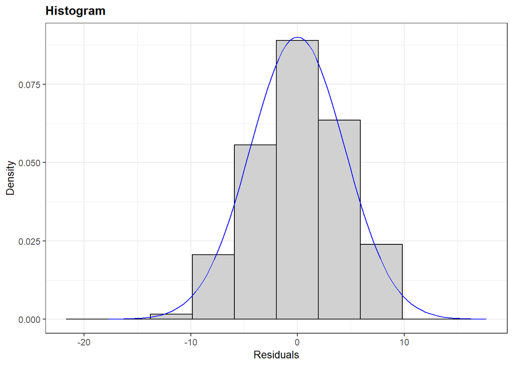

```r
library(ggResidpanel)
resid_panel(additive.lm, plots = 'hist', bins = 10)
```

19. What are the main effects? Calculate an approximate 95% CI for the impact of each main effect (product endorser/corporate credibility) The 95% CI are calculated using the following: (difference in means) $\pm$ (multiplier) (SE residuals) $\times \sqrt{1/n_i + 1/n_j}$ (see p. 91).

The main effects are the differences in group means. For credibility it is 1.49 X 2 = 2.98 and endorser is 1.31 x 2 = 2.62.

```r
# credibility 95% CI:
c(2.98-2*4.456*sqrt(2/80), 2.98+2*4.456*sqrt(2/80))
```

```
## [1] 1.570889 4.389111
```

```r
# endorser 95% CI:
c(2.62-2*4.456*sqrt(2/80), 2.62+2*4.456*sqrt(2/80))
```

```
## [1] 1.210889 4.029111
```